# Biomiot R workshop 3 - beutiful data driven documents with R markdown

by Tomasz Stepkowski

Last modified on 17:04:10 06/03/21

# Introduction to R Markdown

## What is R markdown?

From the [R Markdown Website](http://rmarkdown.rstudio.com):

> *“Analyze. Share. Reproduce. Your data tells a story. Tell it with R Markdown. Turn your analyses into high quality documents, reports, presentations and dashboards.”*

From the introduction of the [Definite guide to R markdown](https://bookdown.org/yihui/rmarkdown/basics.html):

> *“R Markdown provides an authoring framework for data science. You can use a single R Markdown file to both save and execute code, and generate high quality reports that can be shared with an audience. R Markdown was designed for easier reproducibility, since both the computing code and narratives are in the same document, and results are automatically generated from the source code. R Markdown supports dozens of static and dynamic/interactive output formats.If you prefer a video introduction to R Markdown, we recommend that you check out the website https://rmarkdown.rstudio.com, and watch the videos in the “Get Started” section, which cover the basics of R Markdown."*

## What can be created using R markdown?

With R Markdown, you write a single *.Rmd file and then use it to render finished output in a variety of formats:

- Static documents:
  - HTML
  - PDF
  - Word
  - blog
  - Scientific journal style templates available
- Interactive documents:
  - Interactive shiny web apps
  - Static interactive dashboards with embedded HTML widgets
- Presentations
- Books
- Great R coding tutorials like this one:)
- and many other…

## Reproducible is the keyword here!

With R markdown you can easily create `reproducible analyses workflows`. You found an error in the data, new data was added, you need to process it in a slightly different way - you may just need to change one parameter in the input and `voilà` or perform almost everything from scratch…I definitely prefer having a reproducible `*.Rmd` file for my analyses.

# R markdow syntax basics

## Headers

Headers are created using `#` - the number of `#` correspond to the header, subheader(header 2), subsubheader(header 3) etc.

`#### Header 4`

`##### Header 5`

`###### Header 6`

gives:

#### Header 4

##### Header 5

###### Header 6

etc. as you see only headers 1:3 are by default automatically included in the table of contents.

## Inline code formating and code evaluation within text paragraphs

To evaluate r code inside the text block you need to use “r some code” for example to display current date with `Sys.Date()` you can write r Sys.Date() surrounded with ticks which gives 2021-03-06 for the day I have knitted this document .

```r
# evaluating r code inside text paragraphs
# the syntax is as follows `r some code`

# to display r formating use `this will be formatted to code`
```

## Adding code chunks

`````r
# The code chunks are created by introducing
#  ``` {r}
#  This would be a code chunk
#
#  ```` at the beginning of the lines
`````

### Code chunk code options inside `{r}`

|  | Code_is_run | Code_appears_in_report | Results_appear_in_report |
| --- | --- | --- | --- |
| include = FALSE | TRUE | FALSE | FALSE |
| echo = FALSE | TRUE | FALSE | TRUE |
| eval = FALSE | FALSE | TRUE | FALSE |

## Adding links

The syntax for adding links is as follows:

```r
# [Link_name](path)
```

Lets ad link to [Bigest R repository - the CRAN](https://cran.r-project.org/)

## Adding images

The syntax for adding images is as follows:

```r
# ![caption](path)
```

Lets ad the image of the [famous grumpy cat](https://pl.wikipedia.org/wiki/Grumpy_Cat)

[figure not shown]

## Formating text

```r
# **bold** or __bold__
# `*italic* or _italic_
#` ***bold and italic*** or ___bold and italic___
#``~~strikethrough~~
```

gives:

**bold** or **bold**

*italic* or *italic*

*bold and italic* or *bold and italic*

strikethrough

## Adding lists

This is how we create *bullet list*:

`- example`

`- example 2`

or `* example 3`

`* example 4`

will give:

- example
- example 2
- example 3
- example 4

The *ordered* list is created simply with numbers:

`1. Example 1.1`

`2. Example 2.2`

`3. Example 3.3`

1. Example 1.1
2. Example 2.2
3. Example 3.3

## The YAML header

THis is an important part of the *markdown document* in which you can specify different metadata and parameters. It starts and finishes with `---` :

`---`

This would be the body of YAML header

`---`

The intendation is important. Look at the YAML header used to render this document. There are really a lot of options, among others, you can modify:

- output file type: HTML,pdf, ppt, word and many others..
- global graphical appearance: different `theme:` look at the [gallery of example themes](https://www.datadreaming.org/post/r-markdown-theme-gallery/)
- table of contents `toc: true` *impotant!->* YAML uses `true` and `yes` not `TRUE` which is used in r code
- author
- date
- section numbering
- appearance of tables and dataframes `df_print :` [for options see](https://bookdown.org/yihui/rmarkdown/html-document.html#data-frame-printing)
- varying parameters used inside code chunks and many others…

# The NHANES dataset

`library(NHANES)` provides the data from the [US National Health and Nutrition Examination Survey](https://www.cdc.gov/nchs/nhanes/index.htm). It may be considered as a random sample of the US population. We will use it as an example dataset during this workshop.

```r
library(NHANES)  # you may need to install it with install.packages()
library(dplyr)
# Lets  examine the structure of the NHANES dataset
glimpse(NHANES)
```

```
## Rows: 10,000
## Columns: 76
## $ ID               <int> 51624, 51624, 51624, 51625, 51630, 51638, 51646, 5164~
## $ SurveyYr         <fct> 2009_10, 2009_10, 2009_10, 2009_10, 2009_10, 2009_10,~
## $ Gender           <fct> male, male, male, male, female, male, male, female, f~
## $ Age              <int> 34, 34, 34, 4, 49, 9, 8, 45, 45, 45, 66, 58, 54, 10, ~
## $ AgeDecade        <fct>  30-39,  30-39,  30-39,  0-9,  40-49,  0-9,  0-9,  40~
## $ AgeMonths        <int> 409, 409, 409, 49, 596, 115, 101, 541, 541, 541, 795,~
## $ Race1            <fct> White, White, White, Other, White, White, White, Whit~
## $ Race3            <fct> NA, NA, NA, NA, NA, NA, NA, NA, NA, NA, NA, NA, NA, N~
## $ Education        <fct> High School, High School, High School, NA, Some Colle~
## $ MaritalStatus    <fct> Married, Married, Married, NA, LivePartner, NA, NA, M~
## $ HHIncome         <fct> 25000-34999, 25000-34999, 25000-34999, 20000-24999, 3~
## $ HHIncomeMid      <int> 30000, 30000, 30000, 22500, 40000, 87500, 60000, 8750~
## $ Poverty          <dbl> 1.36, 1.36, 1.36, 1.07, 1.91, 1.84, 2.33, 5.00, 5.00,~
```

[output cut: 63 more lines]

```r
# first rows
head(NHANES)
```

| ID | SurveyYr | Gender | Age | AgeDecade | AgeMonths | Race1 | Race3 | Education | MaritalStatus | HHIncome | HHIncomeMid | Poverty | HomeRooms | HomeOwn | Work | Weight | Length | HeadCirc | Height | BMI | BMICatUnder20yrs | BMI_WHO | Pulse | BPSysAve | BPDiaAve | BPSys1 | BPDia1 | BPSys2 | BPDia2 | … |
| --- | --- | --- | --- | --- | --- | --- | --- | --- | --- | --- | --- | --- | --- | --- | --- | --- | --- | --- | --- | --- | --- | --- | --- | --- | --- | --- | --- | --- | --- | --- |
| 51624 | 2009_10 | male | 34 | 30-39 | 409 | White | NA | High School | Married | 25000-34999 | 30000 | 1.36 | 6 | Own | NotWorking | 87.4 | NA | NA | 164.7 | 32.22 | NA | 30.0_plus | 70 | 113 | 85 | 114 | 88 | 114 | 88 | … |
| 51624 | 2009_10 | male | 34 | 30-39 | 409 | White | NA | High School | Married | 25000-34999 | 30000 | 1.36 | 6 | Own | NotWorking | 87.4 | NA | NA | 164.7 | 32.22 | NA | 30.0_plus | 70 | 113 | 85 | 114 | 88 | 114 | 88 | … |
| 51624 | 2009_10 | male | 34 | 30-39 | 409 | White | NA | High School | Married | 25000-34999 | 30000 | 1.36 | 6 | Own | NotWorking | 87.4 | NA | NA | 164.7 | 32.22 | NA | 30.0_plus | 70 | 113 | 85 | 114 | 88 | 114 | 88 | … |
| 51625 | 2009_10 | male | 4 | 0-9 | 49 | Other | NA | NA | NA | 20000-24999 | 22500 | 1.07 | 9 | Own | NA | 17.0 | NA | NA | 105.4 | 15.30 | NA | 12.0_18.5 | NA | NA | NA | NA | NA | NA | NA | … |
| 51630 | 2009_10 | female | 49 | 40-49 | 596 | White | NA | Some College | LivePartner | 35000-44999 | 40000 | 1.91 | 5 | Rent | NotWorking | 86.7 | NA | NA | 168.4 | 30.57 | NA | 30.0_plus | 86 | 112 | 75 | 118 | 82 | 108 | 74 | … |
| 51638 | 2009_10 | male | 9 | 0-9 | 115 | White | NA | NA | NA | 75000-99999 | 87500 | 1.84 | 6 | Rent | NA | 29.8 | NA | NA | 133.1 | 16.82 | NA | 12.0_18.5 | 82 | 86 | 47 | 84 | 50 | 84 | 50 | … |

## Let`s create a variable and reference it in the text of a paragraph

```r
# computing the proportion of man and woman who currently smoke

smoking <- NHANES %>% filter(Education == "Some College") %>%
                      group_by(Gender)%>%
                      summarize(proportion = mean(
                               SmokeNow == "Yes", na.rm = TRUE)
                               )
smoking
```

|  | Gender | proportion |
| --- | --- | --- |
| 1 | female | 0.4390756 |
| 2 | male | 0.4836957 |

### Referencing r variable in the paragraph

> The data in the `NHANES` dataset point that among educated americans the proportions of smoking men and woman are

> |  | Gender | proportion |
> | --- | --- | --- |
> | 1 | female | 0.4390756 |
> | 2 | male | 0.4836957 |

> :

### Rendering preater tables with kable function

WIth `knitr::kable()` and `KableExtra` function we can output nicely designed tables. There are plenty of options…[Vignette on KableExtra](https://cran.r-project.org/web/packages/kableExtra/vignettes/awesome_table_in_html.html)

```r
#default
smoking
```

|  | Gender | proportion |
| --- | --- | --- |
| 1 | female | 0.4390756 |
| 2 | male | 0.4836957 |

```r
#kable
library(knitr)
kable(smoking, caption = "Table 1. The proportion of smokers among american woman and man")
```

Table 1. The proportion of smokers among american woman and man

| Gender | proportion |
| --- | --- |
| female | 0.4390756 |
| male | 0.4836957 |

```r
#KableExtra example
library(kableExtra)
kbl(smoking, caption  = "Classy style :)") %>% kable_classic(full_width = F, html_font = "Cambria")
```

Classy style :)

| Gender | proportion |
| --- | --- |
| female | 0.4390756 |
| male | 0.4836957 |

### Let`s create a simple data visalisation

Here we are creating a simple proportion barchart. Later we will “parametrise” the code above and below (producing table and barchart) - this will allow us to analyse different grouping variable and functions inside summarise().

TO keep your analysis clear it is advised to give your code chunks informative names that differ from the way you name variables or functions. For example I use `-` instead of `_` which I use for object/variable names.

```r
library(ggplot2)

Proportion_barchart <- NHANES %>% filter(Education == "Some College") %>%
                      ggplot(aes(x = Gender, fill = SmokeNow))+
                      geom_bar(position = "Fill")+
                      geom_text(aes(label=scales::percent(..count../sum(..count..))),
                                    stat='count',position=position_fill(vjust=0.5))+
                      theme_classic()

Proportion_barchart
```

[output not shown]

## Customising dimmensions of images and plots

We use `fig.width =` and `fig.height =` inside `{r }` at the beginning of the code chunk. The default unit are inches. You can also specify `dpi =` or proportions of default ouput for example `out.width = "20%"`. Below we produce a wider version of the upper barchart.

```r
Proportion_barchart
```

[output not shown]

## Figure align - center, left, right?

We can display figures at the left, right or center(default) - this is specified by `fig.align = " "`.

```r
Proportion_barchart
```

[output not shown]

## Setting global code chunk options

Different code chunk options such as graphical display of the output or different ways of how code is evaluated and displayed can be set up globally for the whole document. For this we use:

`knitr::opts_chunk$set(fig.align = "left", fig.width = 5, echo = FALSE )`

inside the function you can specify everything that is normally inside `{r}` - `{r what is here can be set up globally }` with `knitr::opts_chunk$set()`

## Adding figure captions inside the code chunk options

Captions can be added in two ways: - as the code chunk option in `{r fig.cap = " "}` - as a part of the plot code (ggplot2 - this library will be covered in another lesson)

```r
Proportion_barchart
```

[output not shown]

## Adding figure captions inside the ggplot2 code

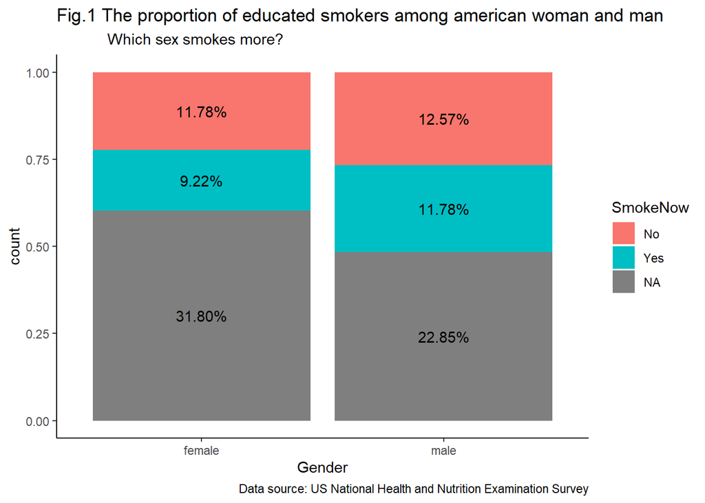

```r
Proportion_barchart+labs(title = "Fig.1 The proportion of educated smokers among american woman and man",
                         subtitle = "            Which sex smokes more?",
                         caption = "Data source: US National Health and Nutrition Examination Survey")
```

## Parameters for reproducible reporting

Here is where it get fancy….In the YAML header you can specify the custom parameters `params:` that will be used to knit your document. Those parameters are referenced in the code `params$parameter_name` and can be anything that is some sort of input like : raw data, different parts of data, different way the functions work, different graphical outputs etc. Below we will take advantage of parameters to create a reproducible version of the table and plot we created previously. The parameters will be named:

- **group_var** with default to: “Gender”
- **analysis_var** with default to: “SmokeNow”
- **education** with default to: “Some College”

```r
#Let`s modify the code that produces table so that it could be used for different types of analysis

library(dplyr)
reproducible_tab <- NHANES %>% filter(Education == params$education) %>%
                      group_by(.data[[params$group_var]]) %>%
                      summarize(proportion = mean(
                               .data[[params$analysis_var]] == "Yes", na.rm = TRUE)
                                                              )

# Do not bother about .data[[ ]] here we will learn about it later - if you are interested see Indirection at https://dplyr.tidyverse.org/articles/programming.html

#This table was created with reproducible code to show the proportion of params$analysis_var among different params$group_var with education status params$education ")

kable(reproducible_tab, caption = paste("Table 2. The proportion of", params$analysis_var, "among different ", params$group_var,  "with education status ", params$education), format = "html", table.attr = "style='width:100%;'")
```

Table 2. The proportion of SmokeNow among different Gender with education status Some College

| Gender | proportion |
| --- | --- |
| female | 0.4390756 |
| male | 0.4836957 |

#### ANd the reprodicible version of the barchart…

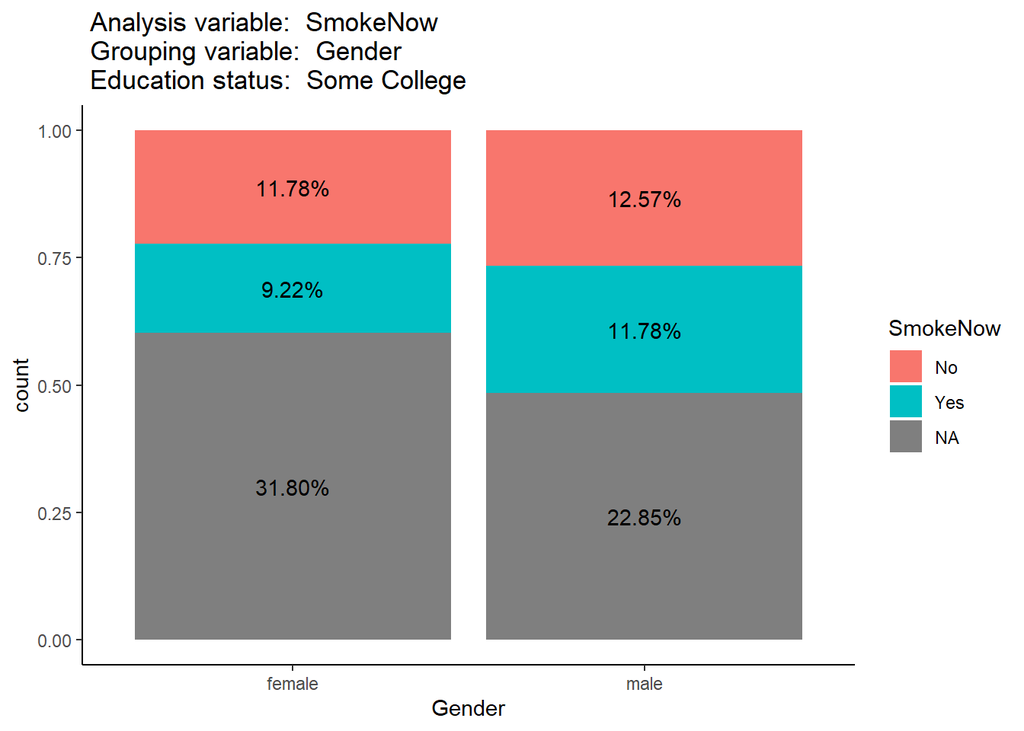

```r
Reproducible_Proportion_barchart <- NHANES %>% filter(Education == params$education) %>%
                      ggplot(aes(x = .data[[params$group_var]], fill = .data[[params$analysis_var]]))+
                      geom_bar(position = "Fill")+
                      geom_text(aes(label=scales::percent(..count../sum(..count..))),
                                    stat='count',position=position_fill(vjust=0.5))+
                      theme_classic()+
                      labs(title =  paste(" Analysis variable: ", params$analysis_var, "\n", "Grouping variable: ", params$group_var, "\n", "Education status: ", params$education))

Reproducible_Proportion_barchart
```

## Lets give it a little more style

### Adding a theme of choice

In the YAML header you will find the `theme:` key in within the `html_output:` . You can choose a different version of theme. [See availible themes you can choose from](https://www.datadreaming.org/post/r-markdown-theme-gallery/).

### Customisation with CSS

Modifying the appearance of the Rmarkdown HTML document with CSS can be done in the following ways:

1. As our Rmarkdown document will be knited to HTML we may use CSS file to add some custom style to it. This can be done with `css: some_style_file.css` in the YAML header.
2. We may also add `<style> </style>` HTML tag at the begining of our R markdown document. This will override the defaults in particular theme. Copy the following code below the YAML header to see how it works:

```
<style>
body {
  color: #960018;
  font-family: Cambria;
  background-color: #D3D3D3
}
</style>
```

3. Using an CSS code chunk with `echo= FALSE` - this will generate the `<style> </style>` tag for you and will display css syntax highlighting which is more convenient.

```css
body {
  color: #960018;
  font-family: Cambria;
  background-color: #D3D3D3
}
```